# Anatomy of a Variable Name

```r
library(dySEM)
```

## Introduction

Most users will follow a four-step process to use dySEM:

> 1. Scrape Variable Information
> 2. Script a Model
> 3. Fit a Model
> 4. Output Desired Values

Of these steps, scraping variable information is one of the most important, yet unintuitive, as researchers do not often take the process of naming their variables for granted.

In this short tutorial, we are going to focus on the patterns of repetition that are present in the variable names in many data sets, and provide a breakdown and vocabulary for the “anatomy” of these variable names. Understanding the elements that make up a variable name will therefore help you to apply more efficient names in your own dataset(s), and to navigate the *scraping* step of using *dySEM* more easily using a function like `scrapeVarCross()`.

## Effective Variable Name Styling

Try to remember the last spreadsheet of data you interacted with. Now think of the variables (i.e., columns) within it. The names of those variables could probably be categorized in terms of a few dimensions of styling, namely, the *clarity* and repetition of the variable name’s *stem* (i.e., the text content of the variable’s name). In terms of clarity, some variable name stems you thought of were probably ambiguous or cryptic (e.g., Q1, Q19_1)–you or someone else wouldn’t immediately be able to understand what kind of data was captured in that variable based on the stem alone.

### Some Examples of Ambiguous Variable Names

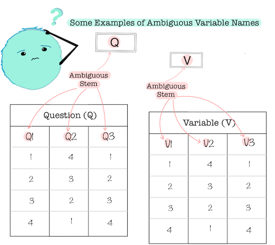

### Some Examples of Intuitive Variable Names

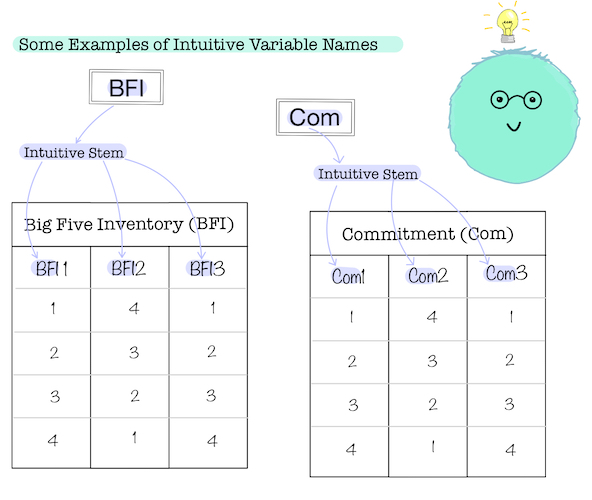

### Some Examples of Inconsistent (oh, the horror) and Consistent Variable Names

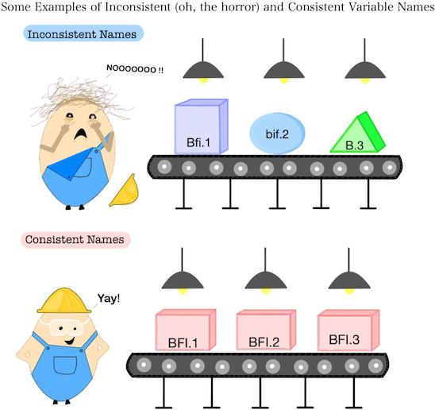

These two dimensions of variable name styling play important, but different, roles when *scraping* variable information via dySEM. Clear names are not essential for scraping functions (e.g., `scrapeVarCross()`) to work properly, but they will make for quicker and less error-prone coding. Repetitious names, meanwhile, are (for now, at least) **essential** for scraping functions. Thus, be sure to export or prepare your dataset in such a way that the related set(s) of variables you intend to use in dySEM have repetitious names.

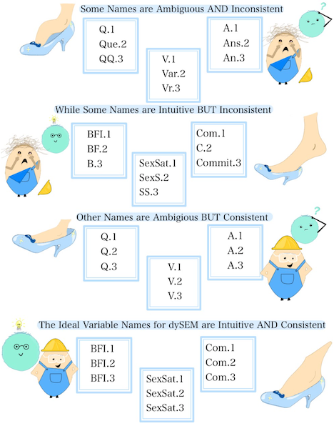

## Double-Trouble with Dyadic Variable Names

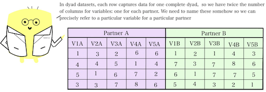

Each variable needs its own unique name, and so typically, dyad datasets involve appending a distinguishing character(s) or number(s) to make clear to which partner’s value a given variable refers. These *distinguishers* come in one of two varieties, corresponding to the type of dyads under study. If the dyads in the dataset are “indistinguishable”–that is, there’s no systematic and consistent way to assign dyad members to a particular role (e.g., friends, coworkers)–then distinguishers are usually arbitrary in name and designation. For example, some partner’s variables might be given the distinguisher “1” or “A”, while the other partner’s variables might be given the distinguisher “2” or “B”. The particular two distinguishers selected in these cases ultimately do not matter (as they do not convey any meaningful role-based information), as long as they are applied repetitiously between dyad members.

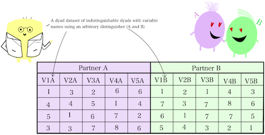

If, alternatively, the dyads in the dataset are “distinguishable”–that is, there’s a systematic role that defines members within a dyad (e.g., heterosexual romantic partners, parent and child, manager and employee, therapist and client)–then there is the opportunity for distinguishers for variable names to be selected for clarity to help you (and others) intuit which partner’s data is captured in which columns.

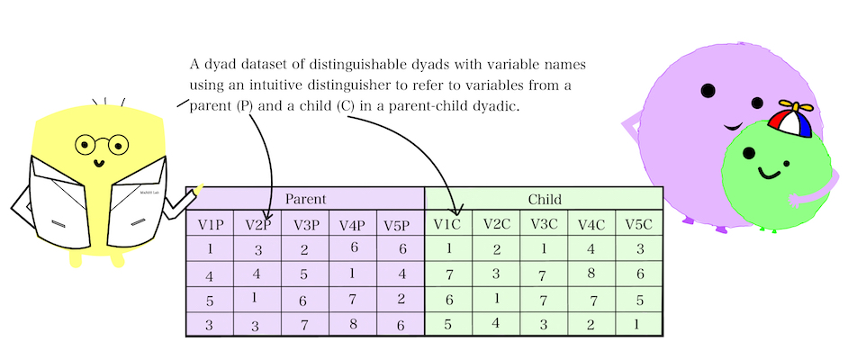

## Dissecting Dyadic Dataset Variable Names

At this point, we have already previewed all of the major features of a variable name in a dyadic dataset–we just need to bring them all together. Understanding these specific features and the labels we use in *dySEM* to refer to them will make it much easier for you when you go to use a scraping function (e.g., `scrapeVarCross()`).

Let’s imagine a hypothetical dataset in which managers and employee dyads both reported on how positively they felt about their respective jobs, using a three-item questionnaire:

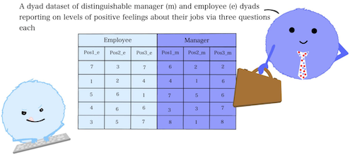

Breaking these names down, we are left with the following component features: The variable *stem*: characters that (ambiguous, or [ideally] intuitive) are consistent across all variables, for both partners that we are interested in (e.g., pos) The *item number*: a number that only appears twice (once per partner) that indicates which specific variable within those sharing its stem is being referenced (e.g., 2) And the *partner distinguisher*: the character that indicates which variables correspond to which partner (e.g., m or e) *Delimiters* such as “.” or “_” can also be used to separate the 1st feature from the 2nd, and the 2nd from the 3rd. Sometimes a name might include one delimiter; other times (as in this case), it might include two.

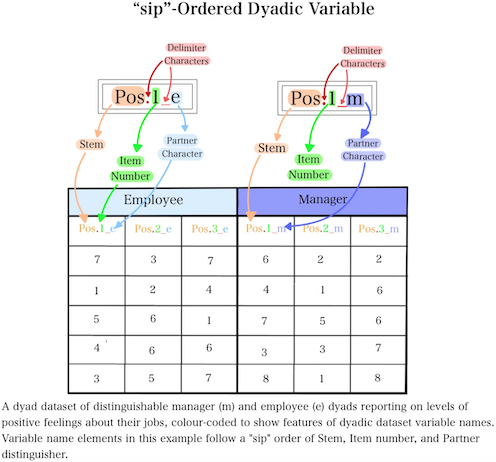

When dyadic dataset variable name features are arranged in this order (*S*tem, *I*tem number, *P*artner distinguisher), we refer to them as **“sip”-ordered** when using dySEM. We do this because variable naming conventions are somewhat arbitrary and varied; people can and do arrange dyadic variable names in other orders. For example, another common ordering is *S*tem, *P*artner distinguisher, *I*tem number, which we refer to as **“spi”-ordered** when using *dySEM*. “spi”-ordered variable names tend to be more common if you used an online survey program like Qualtrics to collect your data (e.g., with questions for both partners embedded in different sections of the same survey).

## Spi-Ordered Dyadic Variable

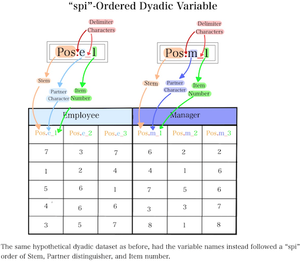

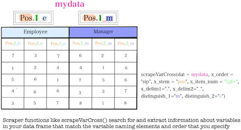